# M08 - Artrite Idiopática Juvenil (AIJ)

## Seguindo com a modelagem dos medicamentos

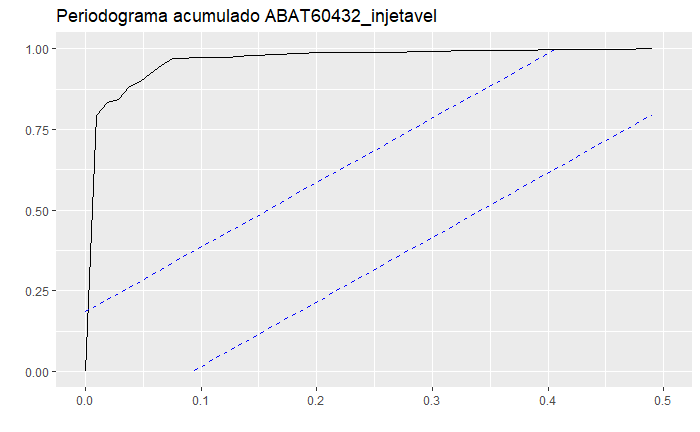

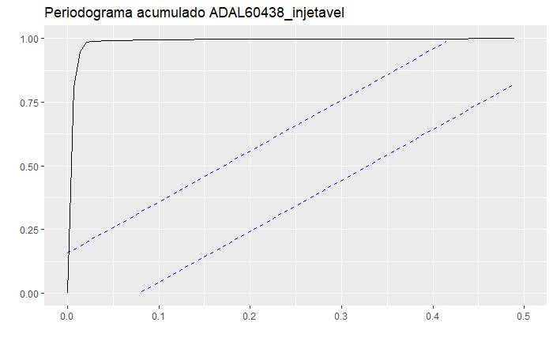

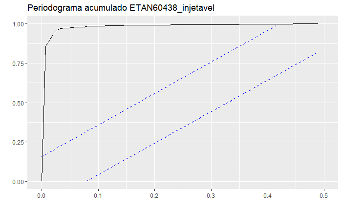

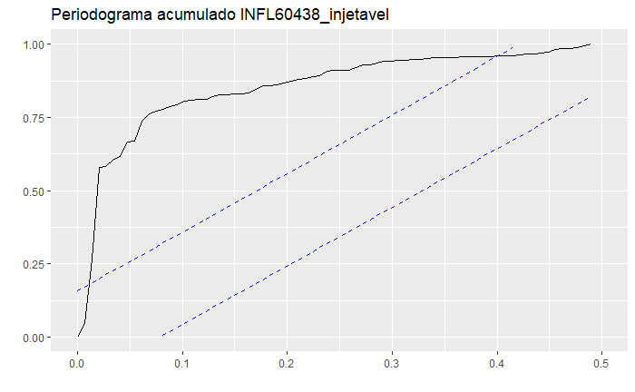

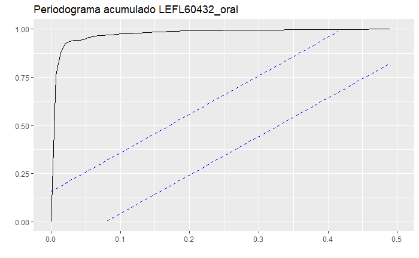

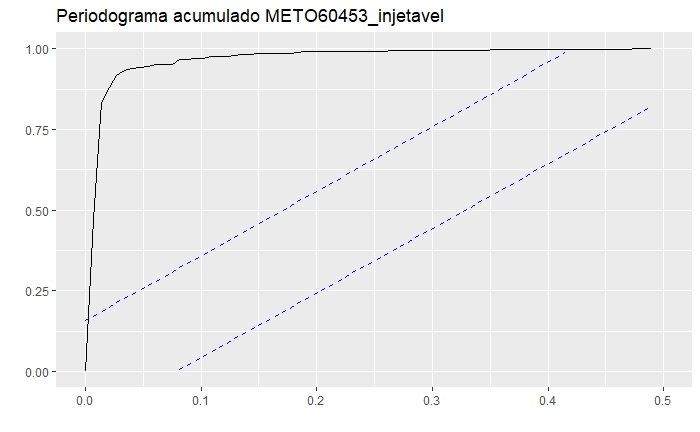

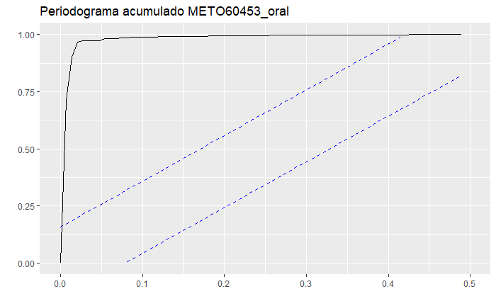

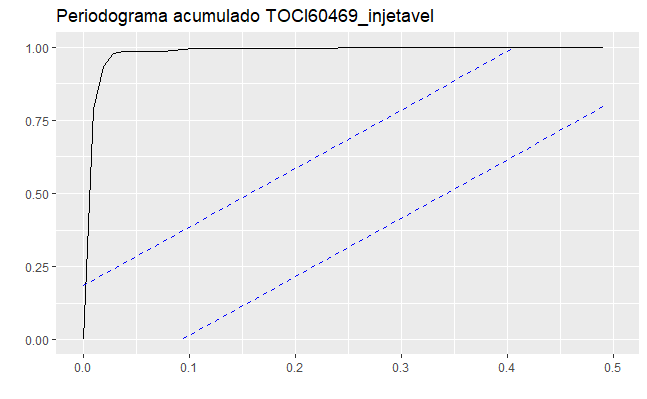

Os periodogramas acumulados de pacientes de todos os medicamentos aponta para a existência de componente sistemático a ser modelado. Sendo assim, a modelagem segue.

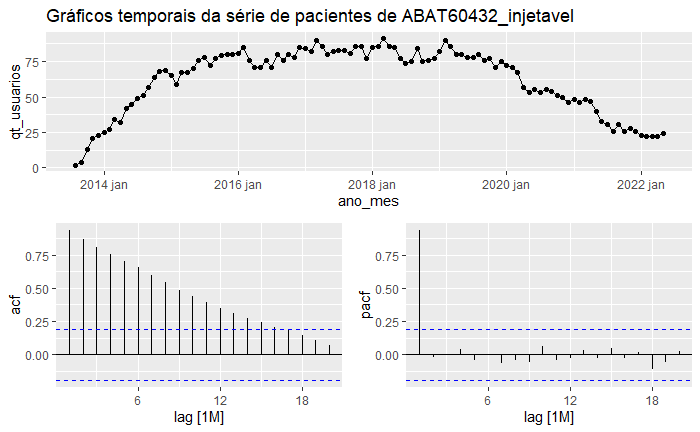

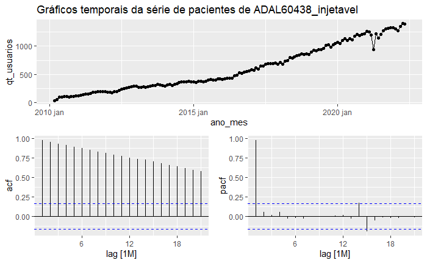

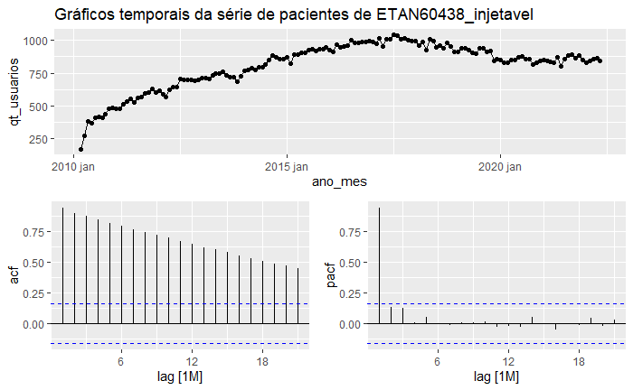

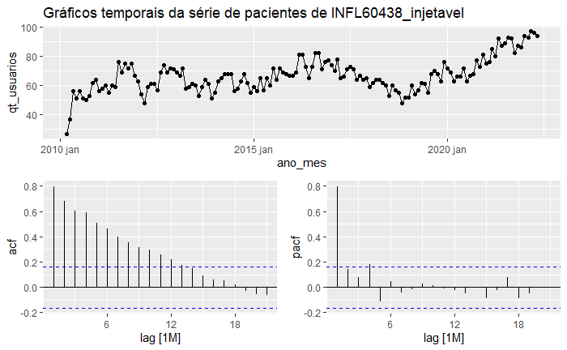

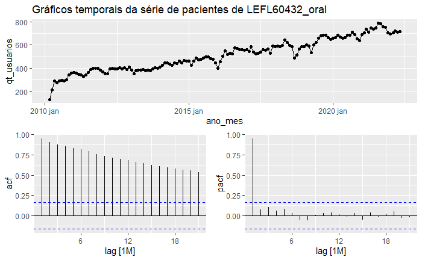

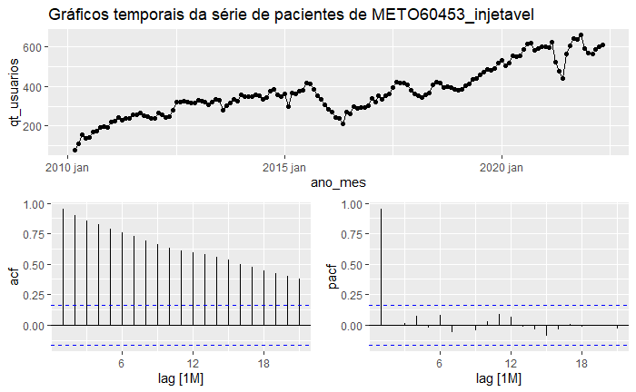

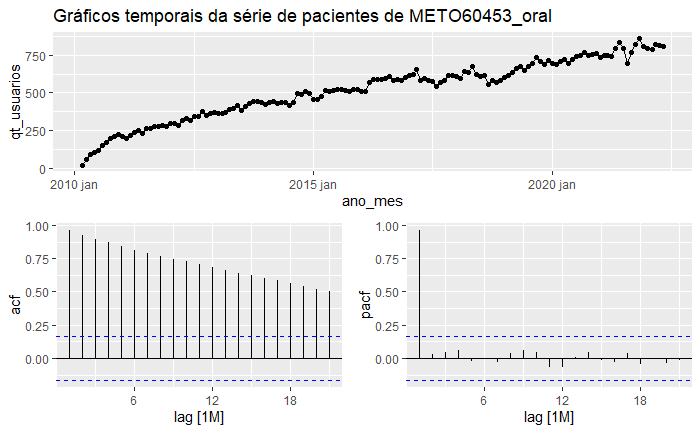

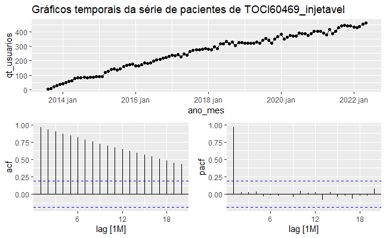

[output not shown]

Não foi possível ajustar o modelo C para os medicamentos cujo número de concorrentes não se alterou durante a série temporal. Desta forma, somente adalimumabe, etanercepte e infliximabe contam com um modelo C ajustado. O mesmo é verificado para o modelo D, pelo mesmo motivo. Como o número de concorrente é constante para estas séries, não há ajuste que possa ser realizado.

```r
mm.t.acc <- meds.models %>%
  accuracy(list(REQM = RMSE), level = 95) %>%
  mutate(periodo = 0, winkler = NaN) %>%
  select(-.type) %>%
  relocate(key, .model, periodo, REQM)
```

| key | .model | metrica | v.0 | v.12 | v.24 |
| --- | --- | --- | --- | --- | --- |
| ABAT60432_injetavel | A | REQM | 4.851693 | 10.083375 | 28.544822 |
| ABAT60432_injetavel | A | winkler | NaN | 45.855649 | 71.025733 |
| ABAT60432_injetavel | B | REQM | 4.670785 | 11.386806 | 13.602246 |
| ABAT60432_injetavel | B | winkler | NaN | 52.863295 | 94.641910 |
| ABAT60432_injetavel | E | REQM | 4.669273 | 10.285238 | 11.610097 |
| ABAT60432_injetavel | E | winkler | NaN | 51.189042 | 90.169837 |
| ABAT60432_injetavel | F | REQM | 4.788281 | 12.304405 | 16.871812 |
| ABAT60432_injetavel | F | winkler | NaN | 40.505263 | 68.115641 |
| ABAT60432_injetavel | G | REQM | 20.130139 | 20.190834 | 33.679082 |
| ABAT60432_injetavel | G | winkler | NaN | 79.876935 | 152.995044 |

[output cut: 82 more lines]

A tabela acima apresenta as métricas dos modelos quando avaliados quanto aos seu resíduos em relação à base de treino e aos dados reais para 12 e 24 meses.

```r
for(i in unique(meds$key)){
  aux <- mm.f.acc %>%
    filter(key == i) %>%
    group_by(key, metrica) %>%
    slice_min(v.0, na_rm = T) %>%
    ungroup() %>%
    union(mm.f.acc %>%
            filter(key == i) %>%
            group_by(key, metrica) %>%
            slice_min(v.12, na_rm = T) %>%
            ungroup()) %>%
    union(mm.f.acc %>%
            filter(key == i) %>%
            group_by(key, metrica) %>%
            slice_min(v.24, na_rm = T) %>% ungroup) %>%
    select(key, .model) %>%
    unique()

  aux %>%
    inner_join(mm.f.acc, by = c("key", ".model")) %>%
    arrange(key, metrica, .model) %>%
    knitr::kable(caption = paste("Modelos para", i, "e suas métricas.")) %>%
    # knitr::kable(caption = paste("Modelos para", i, "e suas métricas."), format = "latex") %>%
    print()

  print(
    meds.cast.24 %>%
      inner_join(aux, by = c("key", ".model")) %>%
      autoplot(meds) +
      scale_x_yearmonth(date_breaks = '1 year', date_labels='%Y') +
      facet_wrap( ~ .model, scales = "free") +
      geom_vline(xintercept = as.Date(max(
        meds.treino$ano_mes
      ) + c(12, 24)), colour = "red") +
      labs(title = paste("Modelos ajustados para ", i),
           caption = "linhas verticais representam 12 e 24 meses de predição.")
  )
}
```

### Adalimumabe

Adalimumabe tem uma especificidade nos dados observados até 12 meses, em que há uma queda brusca no número de pacientes. Esta queda não foi explicada durante a análise e foi julgada imprevisível. Isto posto, os três melhores ajustes quanto ao REQM foram os modelos A (modelo proposto ARIMA(1,1,0) com drift), C (LM com erros ARIMA(0,2,2)) e F (suavização exponencial com erros multiplicativos). Entre eles, o modelo C teve os melhores REQMs para a base de treino (12.33477) e para doze meses (82.48185), ficando em segundo lugar entre os três para 24 meses (71.97500). Por outro lado, o modelo F foi o contrário, obtendo o melhor REQM para 24 meses (69.93844), mas ficando para trás nos outros dois períodos (18.38782 na base de teste e 89.84385 para doze meses). Sendo assim, e analisando os gráficos dos ajustes, sugere-se o uso do modelo C para a predição do número de pacientes de atrite idiopática juvenil tratados com adalimumabe. Contudo, sugere-se cautela e comparação com resultados do modelo A, pois o modelo C depende de informações desconhecidas no momento da predição como a quantidade total de pacientes tratados no SUS com medicamentos do CEAF 1a. Estes dados podem ser preditos usando a estratégia proposta para a demanda aferida, mas isso incorre maior incerteza ao modelo.

### Etanercepte

Etanercepte teve uma queda no número de pacientes começando por volta de 2017. Ao final da série de treino, os números não tinham estabilizado ainda, o que só ocorreu nos meses seguintes. Tendo este comportamento diferente do restante da série, era de se esperar que os modelos não fossem capazes de predizer os números observados. Contudo, apesar de os modelos estimarem médias decrescentes que se distanciam do observado, o modelo D (modelo de decomposição trend + remainder com trend modelado usando LM com erros ARIMA e os parametros qt_concorrentes e qt_total_usuarios) foi capaz de manter os 12 primeiros meses observados dentro de seu intervalo preditivo. O modelo D se destaca quando observado seu escore winkler (220.33266 para 12 meses e 321.22205 para 24 contra 622.25893 e 1670.14981 para os mesmos periodos do modelo C). Isto posto, sugere-se o uso do modelo D para a estimativa de número de pacientes usuários de etanercepte, limitado a 12 meses e tomado o cuidado de considerar a incerteza inerente ao uso de dados estimados para o parâmetro qt_total_usuarios. Finalmente, tendo estabilizado o comportamento da difusão, é possível que um novo ajuste com os dados mais recentes tenha melhor desempenho em predizer números futuros.

### Infliximabe

Os escores dos dois melhores modelos para infliximabe foram próximos. Ambos intervalos preditivos incluíram números entre 40 e 110 pacientes, sem apresentar dados observados fora dos intervalos. Por outro lado, os REQMs do modelo C (ML com erros ARIMA(2,0,1)) foram melhores em todos os intervalos avaliados (base de teste, 12 e 24 meses) quando comparados aos REQM do modelo E (suavização exponencial de Holt). Percebe-se também, pelo gráfico, que a média estimada pela suavização exponencial subestima os valores observados no período. Deve-se, contudo, ter cautela no uso do modelo, pois depende de dados desconhecidos no momento da estimativa, se apoiando em números estimados para a quantidade total de pacientes de AIJ.

### Leflunomida

Os três modelos mais bem avaliados quanto REQM e escore winkler ajustados para leflunomida foram bastante parecidos em desempenho. Os modelos A, B e E (o ARIMA proposto (1,1,0) com drift, o ARIMA selecionado automaticamente (ARIMA(1,0,4) com média) e a suavização exponencial de Holt) tiveram REQM para a base de testes em média 25.72104, com desvio padrão 0.4482104. As médias e desvios padrão para 12 e 24 meses foram: 26.51052 e 0.1571754 para doze meses; e 34.28738 e 0.2565969 para 24. Os escores dos três modelos também tiveram valores parecidos, o que sugere que não haveria diferença em decidir por um ou outro modelo dentres estes.

### Metotrexato injetável

Apesar de um crescimento relativamente estável no número de pacientes, houve duas ocasiões de queda brusca, uma entre 2015 e 2016 e outra 2021. Os modelos mais bem ajustados foram incapazes de predizer a queda de 2021, visto que é um acontecimento incomum. Tanto os gráficos quanto as métricas dos modelos A (modelo proposto ARIMA(1,1,0) com drift) e E (suavização exponencial de Holt) são bastante parecidos, sugerindo que ambos os modelos possam ser usados de maneira intercambiável. Seus REQM tiveram médias 20.6382, 48.67741 e 54.78602 quando avaliados na base de treino, em doze e 24 meses respectivamente, e desvios padrão 0.04860652, 0.1838902 e 0.8321233 para os mesmos períodos, sendo que o modelo E teve os menores REQMs para as bases de validação. Ao mesmo tempo, seus escores tiveram médias 191.3044 e 293.637 para doze e 24 meses, respectivamente, e desvios padrão 1.155865 e 2.965245 para os mesmos períodos, sendo o modelo A o com menor escore para doze meses e o E para 24. Isto posto, pode-se usar qualquer um dos modelos A ou E para a predição do número de pacientes tratados com metotrexato injetável.